# Analisis Faktor-Faktor yang Berkontribusi terhadap Pendapatan Rental Film pada Database Sakila

Annisa Rizky Rarasati

2026-05-26

# 1 Pendahuluan

Industri hiburan visual, khususnya bisnis penyewaan film, memiliki dinamika yang erat kaitannya dengan pengelolaan koleksi film, perilaku pelanggan, serta strategi peningkatan pendapatan. Dalam bisnis rental film, keputusan seperti kategori film apa yang perlu diprioritaskan, pelanggan mana yang paling berkontribusi terhadap pendapatan, serta kapan aktivitas penyewaan paling tinggi menjadi aspek penting yang dapat dianalisis melalui pendekatan berbasis data. Oleh karena itu, data transaksi rental tidak hanya berfungsi sebagai catatan operasional, tetapi juga dapat digunakan sebagai dasar untuk memahami pola bisnis secara lebih objektif.

Database Sakila merupakan database relasional yang merepresentasikan aktivitas bisnis penyewaan film, mulai dari data film, kategori film, pelanggan, inventaris, transaksi rental, hingga pembayaran. Struktur data yang saling terhubung dalam database ini memungkinkan analisis dilakukan secara lebih menyeluruh, terutama dalam melihat hubungan antara produk film, perilaku pelanggan, dan pendapatan yang dihasilkan. Dengan memanfaatkan integrasi MySQL sebagai sistem pengelolaan database dan RStudio sebagai alat komputasi statistik, data Sakila dapat diolah menjadi informasi yang lebih bermakna melalui visualisasi dan analisis data.

Analisis ini bertujuan untuk mengevaluasi performa bisnis penyewaan film berdasarkan beberapa aspek utama, yaitu popularitas kategori film, kontribusi pendapatan, perilaku pelanggan, karakteristik film, serta pola waktu transaksi rental. Untuk mencapai tujuan tersebut, pendekatan analisis yang digunakan dalam laporan ini meliputi:

1. Analisis eksploratif untuk menggambarkan distribusi transaksi rental, pendapatan, kategori film, dan perilaku pelanggan.
2. Analisis regresi linear untuk mengevaluasi faktor-faktor yang berhubungan dengan total pendapatan film.
3. K-Means Clustering untuk mengelompokkan pelanggan berdasarkan perilaku transaksi.
4. Regresi logistik untuk memprediksi risiko keterlambatan pengembalian film.

Melalui analisis ini, diharapkan dapat diperoleh gambaran yang lebih komprehensif mengenai faktor-faktor yang berkontribusi terhadap pendapatan rental film dalam database Sakila. Hasil analisis tidak hanya memberikan informasi mengenai kategori film yang paling diminati, tetapi juga membantu memahami pelanggan yang berperan besar terhadap pendapatan, karakteristik film yang berpotensi memengaruhi performa bisnis, pola permintaan berdasarkan waktu, serta risiko keterlambatan pengembalian film.

**Catatan:** Database Sakila merupakan database contoh, sehingga hasil analisis tidak dapat langsung digeneralisasikan sebagai kondisi bisnis rental film nyata. Namun, struktur datanya tetap relevan untuk latihan eksplorasi data, visualisasi, pemodelan statistik, dan interpretasi bisnis berbasis data.

# 2 Deskripsi Data

Data yang digunakan dalam laporan ini berasal dari database Sakila. Database ini memuat beberapa tabel yang saling berhubungan, seperti tabel film, kategori film, pelanggan, inventaris, transaksi rental, dan pembayaran. Tidak seluruh tabel dalam database digunakan, melainkan hanya tabel yang relevan dengan tujuan analisis.

Tabel utama yang digunakan adalah `film`, `category`, `film_category`, `inventory`, `rental`, `payment`, dan `customer`. Tabel-tabel tersebut digabungkan menggunakan relasi antar-kunci seperti `film_id`, `category_id`, `inventory_id`, `rental_id`, dan `customer_id`.

## 2.1 Load Library & Koneksi ke database Sakila

```r
# Library utama
library(DBI)
library(RMariaDB)
library(dplyr)
library(tidyr)
library(ggplot2)
library(lubridate)
library(knitr)
library(scales)
library(cluster)
library(factoextra)
library(forecast)
library(caret)
library(pROC)
library(broom)

# Pengaturan tampilan angka
options(scipen = 999)
set.seed(123)
```

```r
con <- DBI::dbConnect(odbc::odbc(),
                       Driver = "MySQL ODBC 8.0 ANSI Driver",
                       Server = "127.0.0.1",
                       Database = "sakila",
                       UID    = "root",
                       PWD    = rstudioapi::askForPassword("Masukkan password MySQL:"),
                       Port   = 3306)
```

## 2.2 Tabel yang Digunakan

Tabel-tabel yang digunakan dalam analisis ini dipilih berdasarkan kebutuhan untuk menjawab pertanyaan penelitian. Setiap tabel memiliki peran yang berbeda, mulai dari menyimpan informasi film, kategori, pelanggan, transaksi rental, hingga pembayaran.

```r
tabel_digunakan <- data.frame(
  Tabel = c(
    "film",
    "category",
    "film_category",
    "inventory",
    "rental",
    "payment",
    "customer"
  ),
  Keterangan = c(
    "Memuat informasi film seperti judul, durasi, rating, rental rate, rental duration, dan replacement cost.",
    "Memuat daftar kategori film.",
    "Tabel penghubung antara film dan kategori film.",
    "Memuat informasi stok film yang tersedia di toko.",
    "Memuat data transaksi penyewaan film.",
    "Memuat data pembayaran dari transaksi rental.",
    "Memuat informasi pelanggan."
  )
)

kable(tabel_digunakan, caption = "Tabel yang Digunakan dalam Analisis")
```

Tabel yang Digunakan dalam Analisis

| Tabel | Keterangan |
| --- | --- |
| film | Memuat informasi film seperti judul, durasi, rating, rental rate, rental duration, dan replacement cost. |
| category | Memuat daftar kategori film. |
| film_category | Tabel penghubung antara film dan kategori film. |
| inventory | Memuat informasi stok film yang tersedia di toko. |
| rental | Memuat data transaksi penyewaan film. |
| payment | Memuat data pembayaran dari transaksi rental. |
| customer | Memuat informasi pelanggan. |

Tabel-tabel tersebut dipilih karena mampu merepresentasikan hubungan antara produk film, pelanggan, transaksi rental, dan pendapatan. Dengan menggabungkan tabel tersebut, analisis dapat dilakukan secara lebih menyeluruh.

## 2.3 Mengecek Jumlah Data pada Tabel Utama

Kode ini digunakan untuk melihat jumlah observasi pada masing-masing tabel yang digunakan.

```r
jumlah_tabel <- dbGetQuery(con, "
  SELECT 'film' AS nama_tabel, COUNT(*) AS jumlah_data FROM film
  UNION ALL
  SELECT 'category', COUNT(*) FROM category
  UNION ALL
  SELECT 'film_category', COUNT(*) FROM film_category
  UNION ALL
  SELECT 'inventory', COUNT(*) FROM inventory
  UNION ALL
  SELECT 'rental', COUNT(*) FROM rental
  UNION ALL
  SELECT 'payment', COUNT(*) FROM payment
  UNION ALL
  SELECT 'customer', COUNT(*) FROM customer
")

kable(jumlah_tabel, caption = "Jumlah Data pada Tabel Utama Database Sakila")
```

Jumlah Data pada Tabel Utama Database Sakila

| nama_tabel | jumlah_data |
| --- | --- |
| film | 1000 |
| category | 16 |
| film_category | 1000 |
| inventory | 4581 |
| rental | 16044 |
| payment | 16044 |
| customer | 599 |

Berdasarkan jumlah data pada tabel utama, database Sakila memiliki struktur data yang cukup lengkap untuk menganalisis aktivitas rental film. Tabel `film` menggambarkan jumlah koleksi film, tabel `customer` menggambarkan jumlah pelanggan, sedangkan tabel `rental` dan `payment` menjadi sumber utama untuk menganalisis aktivitas transaksi dan pendapatan.

## 2.4 Penggabungan Data Utama

Dataset utama dibuat dengan menggabungkan tabel payment, rental, customer, inventory, film, film_category, dan category.

```r
data_sakila <- dbGetQuery(con, "
  SELECT
      r.rental_id,
      r.rental_date,
      r.return_date,
      p.payment_id,
      p.amount,
      p.payment_date,
      cu.customer_id,
      CONCAT(cu.first_name, ' ', cu.last_name) AS customer_name,
      f.film_id,
      f.title,
      f.length,
      f.rating,
      f.rental_rate,
      f.rental_duration,
      f.replacement_cost,
      c.name AS category,
      i.store_id
  FROM payment p
  JOIN rental r
      ON p.rental_id = r.rental_id
  JOIN customer cu
      ON p.customer_id = cu.customer_id
  JOIN inventory i
      ON r.inventory_id = i.inventory_id
  JOIN film f
      ON i.film_id = f.film_id
  JOIN film_category fc
      ON f.film_id = fc.film_id
  JOIN category c
      ON fc.category_id = c.category_id
")
head(data_sakila)
```

```
##   rental_id         rental_date         return_date payment_id amount
## 1     10895 2005-08-02 01:16:59 2005-08-03 02:41:59       2104   0.99
## 2     12268 2005-08-18 04:26:54 2005-08-23 06:40:54       1093   0.99
## 3      3150 2005-06-20 20:35:28 2005-06-26 01:01:28        930   0.99
## 4      5072 2005-07-09 05:01:58 2005-07-18 08:17:58       6848   3.99
## 5      9080 2005-07-30 08:02:39 2005-08-06 12:02:39       7479   1.99
## 6     14603 2005-08-21 17:51:06 2005-08-28 15:36:06        715   1.99
##          payment_date customer_id customer_name film_id        title length
## 1 2005-08-02 01:16:59          77  JANE BENNETT      19 AMADEUS HOLY    113
## 2 2005-08-18 04:26:54          39  DEBRA NELSON      19 AMADEUS HOLY    113
## 3 2005-06-20 20:35:28          34 REBECCA SCOTT      19 AMADEUS HOLY    113
## 4 2005-07-09 05:01:58         254  MAXINE SILVA      19 AMADEUS HOLY    113
## 5 2005-07-30 08:02:39         276 BRANDY GRAVES      19 AMADEUS HOLY    113
## 6 2005-08-21 17:51:06          26  JESSICA HALL      19 AMADEUS HOLY    113
##   rating rental_rate rental_duration replacement_cost category store_id
## 1     PG        0.99               6            20.99   Action        1
## 2     PG        0.99               6            20.99   Action        1
## 3     PG        0.99               6            20.99   Action        1
## 4     PG        0.99               6            20.99   Action        1
## 5     PG        0.99               6            20.99   Action        1
## 6     PG        0.99               6            20.99   Action        1
```

Lalu ubah tipe data tanggal dan buat beberapa variabel tambahan.

```r
data_sakila <- data_sakila %>%
  mutate(
    rental_date = as.POSIXct(rental_date),
    return_date = as.POSIXct(return_date),
    payment_date = as.POSIXct(payment_date),

    rental_date_only = as.Date(rental_date),
    rental_month = month(rental_date, label = TRUE, abbr = FALSE),
    rental_day = wday(rental_date, label = TRUE, abbr = FALSE, week_start = 1),
    rental_hour = hour(rental_date),

    actual_rental_duration = as.numeric(
      difftime(return_date, rental_date, units = "days")
    )
  )

head(data_sakila)
```

```
##   rental_id         rental_date         return_date payment_id amount
## 1     10895 2005-08-02 01:16:59 2005-08-03 02:41:59       2104   0.99
## 2     12268 2005-08-18 04:26:54 2005-08-23 06:40:54       1093   0.99
## 3      3150 2005-06-20 20:35:28 2005-06-26 01:01:28        930   0.99
## 4      5072 2005-07-09 05:01:58 2005-07-18 08:17:58       6848   3.99
## 5      9080 2005-07-30 08:02:39 2005-08-06 12:02:39       7479   1.99
## 6     14603 2005-08-21 17:51:06 2005-08-28 15:36:06        715   1.99
##          payment_date customer_id customer_name film_id        title length
## 1 2005-08-02 01:16:59          77  JANE BENNETT      19 AMADEUS HOLY    113
## 2 2005-08-18 04:26:54          39  DEBRA NELSON      19 AMADEUS HOLY    113
## 3 2005-06-20 20:35:28          34 REBECCA SCOTT      19 AMADEUS HOLY    113
## 4 2005-07-09 05:01:58         254  MAXINE SILVA      19 AMADEUS HOLY    113
## 5 2005-07-30 08:02:39         276 BRANDY GRAVES      19 AMADEUS HOLY    113
## 6 2005-08-21 17:51:06          26  JESSICA HALL      19 AMADEUS HOLY    113
##   rating rental_rate rental_duration replacement_cost category store_id
## 1     PG        0.99               6            20.99   Action        1
## 2     PG        0.99               6            20.99   Action        1
## 3     PG        0.99               6            20.99   Action        1
## 4     PG        0.99               6            20.99   Action        1
## 5     PG        0.99               6            20.99   Action        1
## 6     PG        0.99               6            20.99   Action        1
##   rental_date_only rental_month rental_day rental_hour actual_rental_duration
## 1       2005-08-02       August    Tuesday           1               1.059028
## 2       2005-08-18       August   Thursday           4               5.093056
## 3       2005-06-20         June     Monday          20               5.184722
## 4       2005-07-09         July   Saturday           5               9.136111
## 5       2005-07-30         July   Saturday           8               7.166667
## 6       2005-08-21       August     Sunday          17               6.906250
```

## 2.5 Deksripsi Variabel Dataset Utama

Setelah proses penggabungan tabel dilakukan, dataset utama memiliki beberapa variabel yang digunakan untuk mendukung analisis. Variabel tersebut mencakup informasi transaksi, pelanggan, film, kategori, pendapatan, dan waktu rental.

```r
deskripsi_variabel <- data.frame(
  Variabel = c(
    "rental_id",
    "rental_date",
    "return_date",
    "payment_id",
    "amount",
    "payment_date",
    "customer_id",
    "customer_name",
    "film_id",
    "title",
    "length",
    "rating",
    "rental_rate",
    "replacement_cost",
    "category",
    "store_id",
    "rental_month",
    "rental_day",
    "rental_hour",
    "actual_rental_duration"
  ),
  Keterangan = c(
    "ID transaksi rental.",
    "Tanggal dan waktu film disewa.",
    "Tanggal dan waktu film dikembalikan.",
    "ID pembayaran.",
    "Jumlah pembayaran transaksi rental.",
    "Tanggal dan waktu pembayaran.",
    "ID pelanggan.",
    "Nama pelanggan.",
    "ID film.",
    "Judul film.",
    "Durasi film dalam menit.",
    "Rating usia film.",
    "Tarif rental film.",
    "Biaya penggantian film jika terjadi kerusakan atau kehilangan.",
    "Kategori film.",
    "ID toko tempat film tersedia.",
    "Bulan transaksi rental.",
    "Hari transaksi rental.",
    "Jam transaksi rental.",
    "Durasi aktual penyewaan berdasarkan selisih return date dan rental date."
  )
)

kable(deskripsi_variabel, caption = "Deskripsi Variabel Dataset Utama")
```

Deskripsi Variabel Dataset Utama

| Variabel | Keterangan |
| --- | --- |
| rental_id | ID transaksi rental. |
| rental_date | Tanggal dan waktu film disewa. |
| return_date | Tanggal dan waktu film dikembalikan. |
| payment_id | ID pembayaran. |
| amount | Jumlah pembayaran transaksi rental. |
| payment_date | Tanggal dan waktu pembayaran. |
| customer_id | ID pelanggan. |
| customer_name | Nama pelanggan. |
| film_id | ID film. |
| title | Judul film. |
| length | Durasi film dalam menit. |
| rating | Rating usia film. |
| rental_rate | Tarif rental film. |
| replacement_cost | Biaya penggantian film jika terjadi kerusakan atau kehilangan. |
| category | Kategori film. |
| store_id | ID toko tempat film tersedia. |
| rental_month | Bulan transaksi rental. |
| rental_day | Hari transaksi rental. |
| rental_hour | Jam transaksi rental. |
| actual_rental_duration | Durasi aktual penyewaan berdasarkan selisih return date dan rental date. |

## 2.6 Ringkasan Dataset Utama

Bagian ini digunakan untuk menampilkan ukuran dataset yang akan dianalisis.

```r
ringkasan_data <- data_sakila %>%
  summarise(
    jumlah_observasi = n(),
    jumlah_rental = n_distinct(rental_id),
    jumlah_pelanggan = n_distinct(customer_id),
    jumlah_film = n_distinct(film_id),
    jumlah_kategori = n_distinct(category),
    total_pendapatan = sum(amount, na.rm = TRUE),
    rata_rata_pembayaran = mean(amount, na.rm = TRUE),
    rata_rata_durasi_film = mean(length, na.rm = TRUE)
  ) %>%
  pivot_longer(
    cols = everything(),
    names_to = "Indikator",
    values_to = "Nilai"
  )

kable(
  ringkasan_data,
  caption = "Ringkasan Dataset Utama",
  digits = 2
)
```

Ringkasan Dataset Utama

| Indikator | Nilai |
| --- | --- |
| jumlah_observasi | 16044.00 |
| jumlah_rental | 16044.00 |
| jumlah_pelanggan | 599.00 |
| jumlah_film | 958.00 |
| jumlah_kategori | 16.00 |
| total_pendapatan | 67406.56 |
| rata_rata_pembayaran | 4.20 |
| rata_rata_durasi_film | 114.97 |

Ringkasan dataset menunjukkan bahwa data Sakila memiliki informasi yang cukup untuk menganalisis performa bisnis rental film. Total rental menunjukkan volume aktivitas transaksi, total pelanggan menunjukkan cakupan konsumen, sedangkan total pendapatan menjadi indikator utama performa finansial.

# 3 Preprocessing dan Penanganan Missing Value

Sebelum dilakukan analisis, data perlu diperiksa untuk memastikan kualitasnya. Salah satu tahap penting dalam preprocessing adalah memeriksa missing value, terutama pada variabel yang akan digunakan dalam analisis statistik.

## 3.1 Pemeriksaan Missing Value

Pemeriksaan missing value dilakukan untuk memastikan kualitas data sebelum dianalisis lebih lanjut. Variabel dengan missing value perlu diperhatikan karena dapat memengaruhi hasil analisis.

```r
missing_value <- data_sakila %>%
  summarise(across(everything(), ~ sum(is.na(.)))) %>%
  pivot_longer(
    cols = everything(),
    names_to = "variabel",
    values_to = "jumlah_missing"
  ) %>%
  arrange(desc(jumlah_missing))

kable(missing_value, caption = "Jumlah Missing Value pada Dataset Utama")
```

Jumlah Missing Value pada Dataset Utama

| variabel | jumlah_missing |
| --- | --- |
| return_date | 183 |
| actual_rental_duration | 183 |
| rental_id | 0 |
| rental_date | 0 |
| payment_id | 0 |
| amount | 0 |
| payment_date | 0 |
| customer_id | 0 |
| customer_name | 0 |
| film_id | 0 |
| title | 0 |
| length | 0 |
| rating | 0 |
| rental_rate | 0 |
| rental_duration | 0 |
| replacement_cost | 0 |
| category | 0 |
| store_id | 0 |
| rental_date_only | 0 |
| rental_month | 0 |
| rental_day | 0 |
| rental_hour | 0 |

Berdasarkan pemeriksaan missing value, nilai kosong ditemukan pada variabel `return_date` dan `actual_rental_duration`. Missing value pada `actual_rental_duration` terjadi karena variabel tersebut dihitung dari selisih antara `return_date` dan `rental_date`. Jika `return_date` kosong, maka durasi aktual rental juga tidak dapat dihitung.

## 3.2 Penanganan Missing Value

Menambahkan variabel baru yaitu status pengembalian.

```r
data_sakila <- data_sakila %>%
  mutate(
    status_pengembalian = ifelse(
      is.na(return_date),
      "Belum tercatat kembali",
      "Sudah kembali"
    )
  )
status_pengembalian <- data_sakila %>%
  count(status_pengembalian) %>%
  mutate(
    persentase = round(n / sum(n) * 100, 2)
  )

kable(status_pengembalian, caption = "Distribusi Status Pengembalian Film")
```

Distribusi Status Pengembalian Film

| status_pengembalian | n | persentase |
| --- | --- | --- |
| Belum tercatat kembali | 183 | 1.14 |
| Sudah kembali | 15861 | 98.86 |

```r
data_sakila_returned <- data_sakila %>%
  filter(!is.na(return_date), !is.na(actual_rental_duration))
```

Missing value tidak langsung dihapus dari dataset utama karena sebagian besar analisis, seperti analisis kategori film, pendapatan, pelanggan, dan pola waktu rental, tidak bergantung pada variabel `return_date`. Variabel penting seperti `amount`, `category`, `rental_date`, `customer_id`, `film_id`, dan `rental_rate` tidak memiliki missing value, sehingga tetap dapat digunakan.

Namun, untuk analisis yang membutuhkan durasi aktual rental, seperti prediksi keterlambatan pengembalian, hanya digunakan data yang telah memiliki `return_date`.

**Catatan:** Menghapus seluruh baris yang memiliki missing value dapat menyebabkan hilangnya transaksi yang sebenarnya masih berguna untuk analisis pendapatan dan pola rental. Oleh karena itu, penanganan missing value dilakukan secara selektif sesuai kebutuhan analisis.

# 4 Analisis Eksploratif Data

Analisis eksploratif dilakukan untuk memahami pola awal pada data sebelum masuk ke analisis statistik lanjutan. Bagian ini mencakup analisis kategori film, perilaku pelanggan, dan pola waktu rental.

## 4.1 Analisis Kategori Film dan Pendapatan

Analisis kategori film dilakukan untuk mengetahui kategori film yang paling populer dan paling berkontribusi terhadap pendapatan rental. Dalam konteks bisnis, kategori dengan jumlah rental tinggi menunjukkan popularitas, sedangkan kategori dengan total pendapatan tinggi menunjukkan kontribusi finansial.

### 4.1.1 Ringkasan Data Berdasarkan Kategori

```r
data_kategori <- data_sakila %>%
  group_by(category) %>%
  summarise(
    total_rental = n_distinct(rental_id),
    total_revenue = sum(amount, na.rm = TRUE),
    avg_payment = mean(amount, na.rm = TRUE),
    avg_rental_rate = mean(rental_rate, na.rm = TRUE),
    jumlah_film = n_distinct(film_id),
    .groups = "drop"
  ) %>%
  arrange(desc(total_revenue))

kable(
  data_kategori,
  caption = "Ringkasan Jumlah Rental dan Pendapatan Berdasarkan Kategori Film",
  digits = 2
)
```

Ringkasan Jumlah Rental dan Pendapatan Berdasarkan Kategori Film

| category | total_rental | total_revenue | avg_payment | avg_rental_rate | jumlah_film |
| --- | --- | --- | --- | --- | --- |
| Sports | 1179 | 5314.21 | 4.51 | 3.07 | 73 |
| Sci-Fi | 1101 | 4756.98 | 4.32 | 2.99 | 59 |
| Animation | 1166 | 4656.30 | 3.99 | 2.76 | 64 |
| Drama | 1060 | 4587.39 | 4.33 | 3.18 | 61 |
| Comedy | 941 | 4383.58 | 4.66 | 3.28 | 56 |
| Action | 1112 | 4375.85 | 3.94 | 2.67 | 61 |
| New | 940 | 4351.62 | 4.63 | 3.09 | 60 |
| Games | 969 | 4281.33 | 4.42 | 3.13 | 58 |
| Foreign | 1033 | 4270.67 | 4.13 | 2.95 | 67 |
| Family | 1096 | 4226.07 | 3.86 | 2.70 | 67 |
| Documentary | 1050 | 4217.52 | 4.02 | 2.62 | 63 |
| Horror | 846 | 3722.54 | 4.40 | 3.10 | 53 |
| Children | 945 | 3655.55 | 3.87 | 2.69 | 58 |
| Classics | 939 | 3639.59 | 3.88 | 2.64 | 54 |
| Travel | 837 | 3549.64 | 4.24 | 3.32 | 53 |
| Music | 830 | 3417.72 | 4.12 | 3.06 | 51 |

Berdasarkan tabel ringkasan kategori, setiap kategori film memiliki jumlah rental dan total pendapatan yang berbeda. Perbedaan ini menunjukkan bahwa tidak semua kategori memiliki kontribusi yang sama terhadap performa bisnis rental. Kategori dengan total pendapatan terbesar dapat dianggap sebagai kategori yang paling berkontribusi terhadap pemasukan, sedangkan kategori dengan jumlah rental tertinggi menunjukkan kategori yang paling sering dipilih oleh pelanggan.

### 4.1.2 Kategori dengan Pendapatan dan Rental Tertinggi

```r
top_revenue_category <- data_kategori %>%
  slice_max(total_revenue, n = 1, with_ties = FALSE)

top_rental_category <- data_kategori %>%
  slice_max(total_rental, n = 1, with_ties = FALSE)

top_avg_payment_category <- data_kategori %>%
  slice_max(avg_payment, n = 1, with_ties = FALSE)

kable(
  top_revenue_category,
  caption = "Kategori Film dengan Total Pendapatan Tertinggi",
  digits = 2
)
```

Kategori Film dengan Total Pendapatan Tertinggi

| category | total_rental | total_revenue | avg_payment | avg_rental_rate | jumlah_film |
| --- | --- | --- | --- | --- | --- |
| Sports | 1179 | 5314.21 | 4.51 | 3.07 | 73 |

```r
kable(
  top_rental_category,
  caption = "Kategori Film dengan Jumlah Rental Tertinggi",
  digits = 2
)
```

Kategori Film dengan Jumlah Rental Tertinggi

| category | total_rental | total_revenue | avg_payment | avg_rental_rate | jumlah_film |
| --- | --- | --- | --- | --- | --- |
| Sports | 1179 | 5314.21 | 4.51 | 3.07 | 73 |

```r
kable(
  top_avg_payment_category,
  caption = "Kategori Film dengan Rata-Rata Pembayaran Tertinggi",
  digits = 2
)
```

Kategori Film dengan Rata-Rata Pembayaran Tertinggi

| category | total_rental | total_revenue | avg_payment | avg_rental_rate | jumlah_film |
| --- | --- | --- | --- | --- | --- |
| Comedy | 941 | 4383.58 | 4.66 | 3.28 | 56 |

Kategori dengan total pendapatan tertinggi adalah **Sports** dengan total pendapatan sebesar **$5314.21**. Sementara itu, kategori dengan jumlah rental tertinggi adalah **Sports** dengan jumlah rental sebanyak **1179** transaksi.

Hal ini penting untuk diperhatikan karena kategori dengan jumlah rental terbanyak belum tentu selalu menjadi kategori dengan pendapatan terbesar. Jika terdapat perbedaan antara kategori paling sering disewa dan kategori paling tinggi pendapatannya, maka dapat dikatakan bahwa jumlah transaksi bukan satu-satunya faktor yang menentukan pendapatan. Nilai pembayaran rata-rata dan tarif rental juga perlu dipertimbangkan.

### 4.1.3 Visualisasi Total Pendapatan Berdasarkan Kategori Film

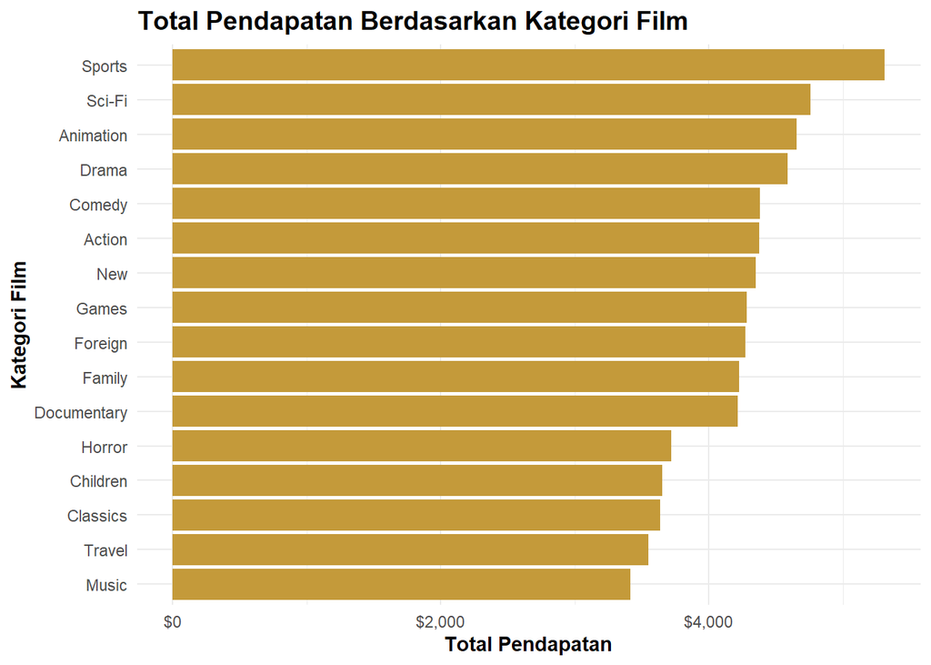

```r
ggplot(data_kategori, aes(x = reorder(category, total_revenue), y = total_revenue)) +
  geom_col(fill = "#c49a3a") +
  coord_flip() +
  scale_y_continuous(labels = dollar_format(prefix = "$")) +
  labs(
    title = "Total Pendapatan Berdasarkan Kategori Film",
    x = "Kategori Film",
    y = "Total Pendapatan"
  ) +
  theme_minimal() +
  theme(
    plot.title = element_text(face = "bold", size = 14),
    axis.title = element_text(face = "bold")
  )
```

Visualisasi di atas menunjukkan perbandingan total pendapatan pada setiap kategori film. Kategori yang berada pada posisi teratas merupakan kategori dengan kontribusi pendapatan paling besar terhadap bisnis rental. Semakin panjang batang pada grafik, semakin besar total pendapatan yang dihasilkan oleh kategori tersebut.

Dari sisi bisnis, kategori dengan pendapatan tinggi dapat menjadi prioritas dalam pengelolaan koleksi film. Toko rental dapat mempertimbangkan untuk menjaga ketersediaan film pada kategori tersebut karena kategori tersebut terbukti memberikan kontribusi pendapatan yang relatif besar.

### 4.1.4 Visualisasi Jumlah Rental Berdasarkan Kategori Film

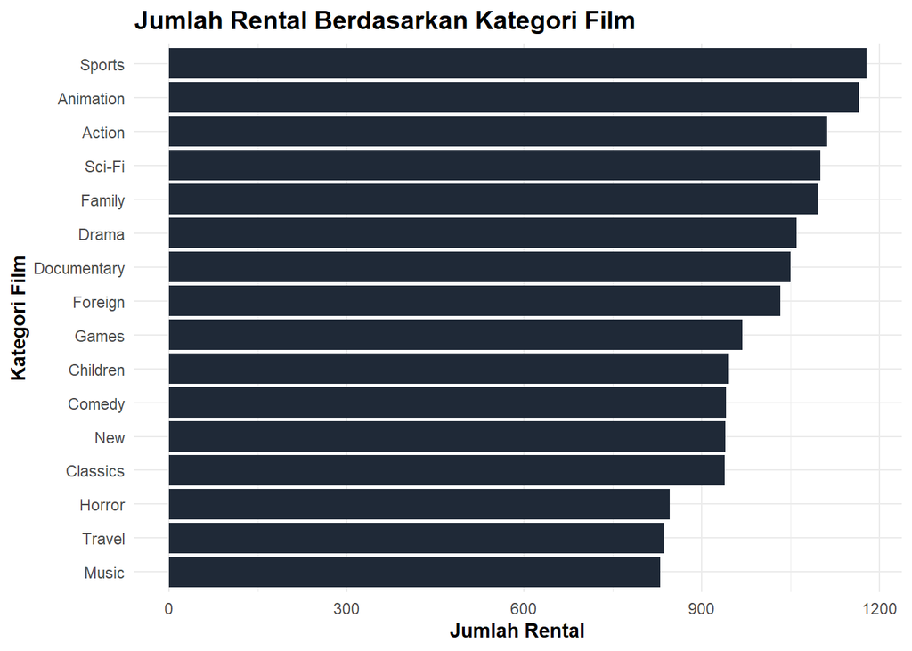

```r
ggplot(data_kategori, aes(x = reorder(category, total_rental), y = total_rental)) +
  geom_col(fill = "#1f2937") +
  coord_flip() +
  labs(
    title = "Jumlah Rental Berdasarkan Kategori Film",
    x = "Kategori Film",
    y = "Jumlah Rental"
  ) +
  theme_minimal() +
  theme(
    plot.title = element_text(face = "bold", size = 14),
    axis.title = element_text(face = "bold")
  )
```

Grafik jumlah rental menunjukkan kategori film yang paling sering disewa oleh pelanggan. Kategori dengan jumlah rental tinggi dapat diartikan sebagai kategori yang memiliki tingkat popularitas lebih besar dibandingkan kategori lainnya. Namun, popularitas berdasarkan jumlah rental perlu dibandingkan dengan total pendapatan agar dapat diketahui apakah kategori yang sering disewa juga benar-benar memberikan kontribusi pendapatan yang tinggi.

### 4.1.5 Scatter Plot Jumlah Rental dan Total Pendapatan

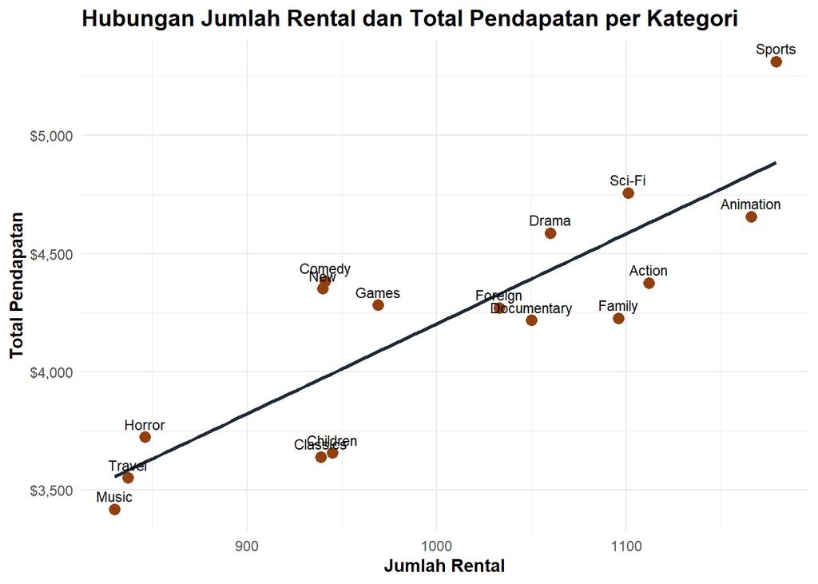

```r
ggplot(data_kategori, aes(x = total_rental, y = total_revenue, label = category)) +
  geom_point(size = 3, color = "#92400e") +
  geom_smooth(method = "lm", se = FALSE, color = "#1f2937") +
  geom_text(vjust = -0.7, size = 3) +
  scale_y_continuous(labels = dollar_format(prefix = "$")) +
  labs(
    title = "Hubungan Jumlah Rental dan Total Pendapatan per Kategori",
    x = "Jumlah Rental",
    y = "Total Pendapatan"
  ) +
  theme_minimal() +
  theme(
    plot.title = element_text(face = "bold", size = 14),
    axis.title = element_text(face = "bold")
  )
```

Scatter plot digunakan untuk melihat pola hubungan antara jumlah rental dan total pendapatan pada setiap kategori film. Titik yang berada semakin ke kanan menunjukkan kategori dengan jumlah rental lebih tinggi, sedangkan titik yang semakin ke atas menunjukkan kategori dengan total pendapatan lebih besar.

Jika titik-titik pada grafik cenderung membentuk pola naik dari kiri bawah ke kanan atas, maka dapat dikatakan bahwa kategori dengan jumlah rental tinggi cenderung menghasilkan pendapatan yang tinggi pula. Namun, jika terdapat kategori yang posisinya menyimpang dari pola umum, kategori tersebut perlu dianalisis lebih lanjut karena dapat menunjukkan karakteristik khusus, misalnya rata-rata pembayaran yang lebih tinggi atau lebih rendah dibanding kategori lainnya.

### 4.1.6 Analisis Korelasi Jumlah Rental dan Total Pendapatan

Untuk mengukur kekuatan hubungan antara jumlah rental dan total pendapatan, digunakan analisis korelasi Pearson. Rumus korelasi Pearson adalah sebagai berikut:

$$r = \frac{\sum (x_i - \bar{x})(y_i -
\bar{y})}
{\sqrt{\sum (x_i - \bar{x})^2 \sum (y_i - \bar{y})^2}}$$

Keterangan:

- $x_i$ = jumlah rental kategori ke-i
- $y_i$ = total pendapatan kategori ke-i
- $\bar{x}$ = rata-rata jumlah rental
- $\bar{y}$ = rata-rata total pendapatan
- $r$ = koefisien korelasi Pearson

```r
uji_korelasi_kategori <- cor.test(
  data_kategori$total_rental,
  data_kategori$total_revenue,
  method = "pearson"
)

hasil_korelasi_kategori <- data.frame(
  koefisien_korelasi = round(uji_korelasi_kategori$estimate, 4),
  p_value = format.pval(uji_korelasi_kategori$p.value, digits = 4, eps = 0.0001),
  metode = uji_korelasi_kategori$method
)

kable(hasil_korelasi_kategori, caption = "Hasil Korelasi Jumlah Rental dan Total Pendapatan Kategori")
```

Hasil Korelasi Jumlah Rental dan Total Pendapatan Kategori

|  | koefisien_korelasi | p_value | metode |
| --- | --- | --- | --- |
| cor | 0.8487 | < 0.0001 | Pearson’s product-moment correlation |

Berdasarkan hasil uji korelasi Pearson, diperoleh nilai koefisien korelasi sebesar **0.849** dengan nilai p-value sebesar **0**.

Nilai koefisien korelasi tersebut menunjukkan arah dan kekuatan hubungan antara jumlah rental dan total pendapatan. Jika nilai korelasi bernilai positif, maka hubungan yang terbentuk bersifat searah, artinya semakin tinggi jumlah rental pada suatu kategori, semakin besar pula total pendapatan yang dihasilkan. Sebaliknya, jika nilai korelasi mendekati nol, maka hubungan antara jumlah rental dan pendapatan cenderung lemah.

Dalam konteks bisnis rental film, hasil ini dapat digunakan untuk menilai apakah popularitas kategori film benar-benar berkaitan dengan kontribusi pendapatan. Namun, interpretasi korelasi tetap perlu dilakukan secara hati-hati karena jumlah kategori film dalam database Sakila terbatas, sehingga hasil korelasi lebih tepat dipahami sebagai indikasi pola hubungan, bukan sebagai bukti sebab-akibat mutlak.

**Catatan:** Analisis korelasi hanya menunjukkan hubungan antara jumlah rental dan total pendapatan, bukan hubungan sebab-akibat. Kategori dengan jumlah rental tinggi cenderung menghasilkan pendapatan besar, tetapi pendapatan juga dapat dipengaruhi oleh faktor lain seperti tarif rental, rata-rata pembayaran, jumlah film dalam kategori, dan frekuensi ketersediaan inventaris.

**Kesimpulan sementara:** Analisis kategori film menunjukkan bahwa performa bisnis rental tidak hanya dapat dilihat dari jumlah film yang disewa, tetapi juga dari pendapatan yang dihasilkan. Kategori dengan jumlah rental tinggi menunjukkan popularitas, sedangkan kategori dengan total pendapatan tinggi menunjukkan kontribusi finansial yang besar. Oleh karena itu, kedua indikator tersebut perlu dianalisis secara bersamaan agar keputusan bisnis tidak hanya didasarkan pada banyaknya transaksi, tetapi juga pada nilai pendapatan yang dihasilkan.

## 4.2 Analisis Perilaku Pelanggan

Analisis perilaku pelanggan dilakukan untuk mengetahui pelanggan yang paling aktif dan paling berkontribusi terhadap pendapatan. Analisis ini menjadi dasar sebelum dilakukan segmentasi pelanggan menggunakan K-Means Clustering.

### 4.2.1 Top 10 Pelanggan Berdasarkan Total Pembayaran

```r
data_pelanggan <- data_sakila %>%
  group_by(customer_id, customer_name) %>%
  summarise(
    total_rental = n_distinct(rental_id),
    total_payment = sum(amount, na.rm = TRUE),
    avg_payment = mean(amount, na.rm = TRUE),
    first_rental_date = min(rental_date, na.rm = TRUE),
    last_rental_date = max(rental_date, na.rm = TRUE),
    .groups = "drop"
  ) %>%
  arrange(desc(total_payment))

kable(head(data_pelanggan, 10), caption = "Top 10 Pelanggan Berdasarkan Total Pembayaran", digits = 2)
```

Top 10 Pelanggan Berdasarkan Total Pembayaran

| customer_id | customer_name | total_rental | total_payment | avg_payment | first_rental_date | last_rental_date |
| --- | --- | --- | --- | --- | --- | --- |
| 526 | KARL SEAL | 45 | 221.55 | 4.92 | 2005-05-28 00:40:48 | 2005-08-23 22:21:03 |
| 148 | ELEANOR HUNT | 46 | 216.54 | 4.71 | 2005-05-28 23:53:18 | 2005-08-23 05:57:04 |
| 144 | CLARA SHAW | 42 | 195.58 | 4.66 | 2005-05-27 00:49:27 | 2005-08-23 12:43:30 |
| 137 | RHONDA KENNEDY | 39 | 194.61 | 4.99 | 2005-05-30 12:13:52 | 2005-08-23 21:56:04 |
| 178 | MARION SNYDER | 39 | 194.61 | 4.99 | 2005-06-15 09:03:52 | 2006-02-14 15:16:03 |
| 459 | TOMMY COLLAZO | 38 | 186.62 | 4.91 | 2005-05-24 22:54:33 | 2005-08-23 14:52:50 |
| 469 | WESLEY BULL | 40 | 177.60 | 4.44 | 2005-05-26 03:07:43 | 2005-08-23 15:46:33 |
| 468 | TIM CARY | 39 | 175.61 | 4.50 | 2005-05-25 17:17:04 | 2005-08-23 22:24:39 |
| 236 | MARCIA DEAN | 42 | 175.58 | 4.18 | 2005-05-26 15:46:56 | 2006-02-14 15:16:03 |
| 181 | ANA BRADLEY | 34 | 174.66 | 5.14 | 2005-05-28 11:19:23 | 2006-02-14 15:16:03 |

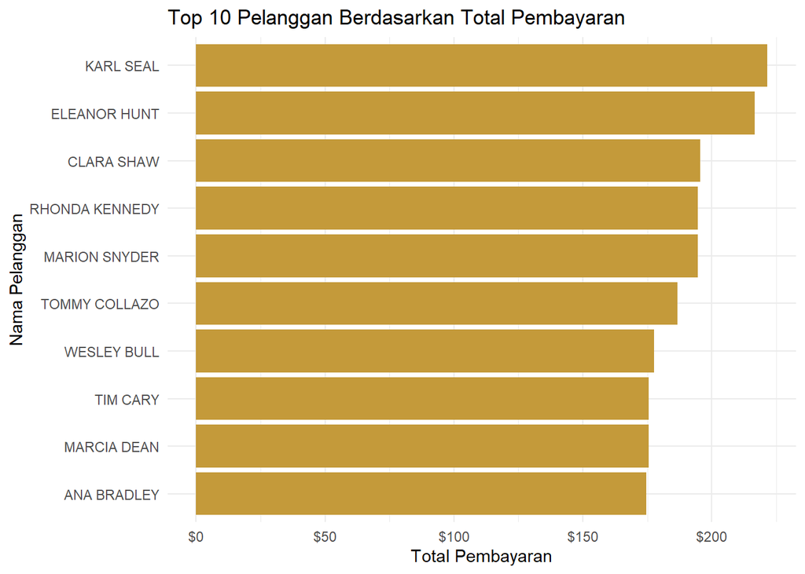

```r
top10_pelanggan <- data_pelanggan %>%
  slice_max(total_payment, n = 10)

ggplot(top10_pelanggan, aes(x = reorder(customer_name, total_payment), y = total_payment)) +
  geom_col(fill = "#c49a3a") +
  coord_flip() +
  scale_y_continuous(labels = dollar_format(prefix = "$")) +
  labs(
    title = "Top 10 Pelanggan Berdasarkan Total Pembayaran",
    x = "Nama Pelanggan",
    y = "Total Pembayaran"
  ) +
  theme_minimal()
```

Grafik di atas menunjukkan sepuluh pelanggan dengan total pembayaran tertinggi. Pelanggan pada posisi teratas dapat dianggap sebagai pelanggan bernilai tinggi karena memberikan kontribusi pendapatan paling besar. Namun, total pembayaran perlu dibaca bersama jumlah rental, karena pelanggan dengan total pembayaran tinggi bisa saja disebabkan oleh frekuensi rental yang tinggi.

### 4.2.2 Scatter Plot Jumlah Rental dan Total Pembayaran

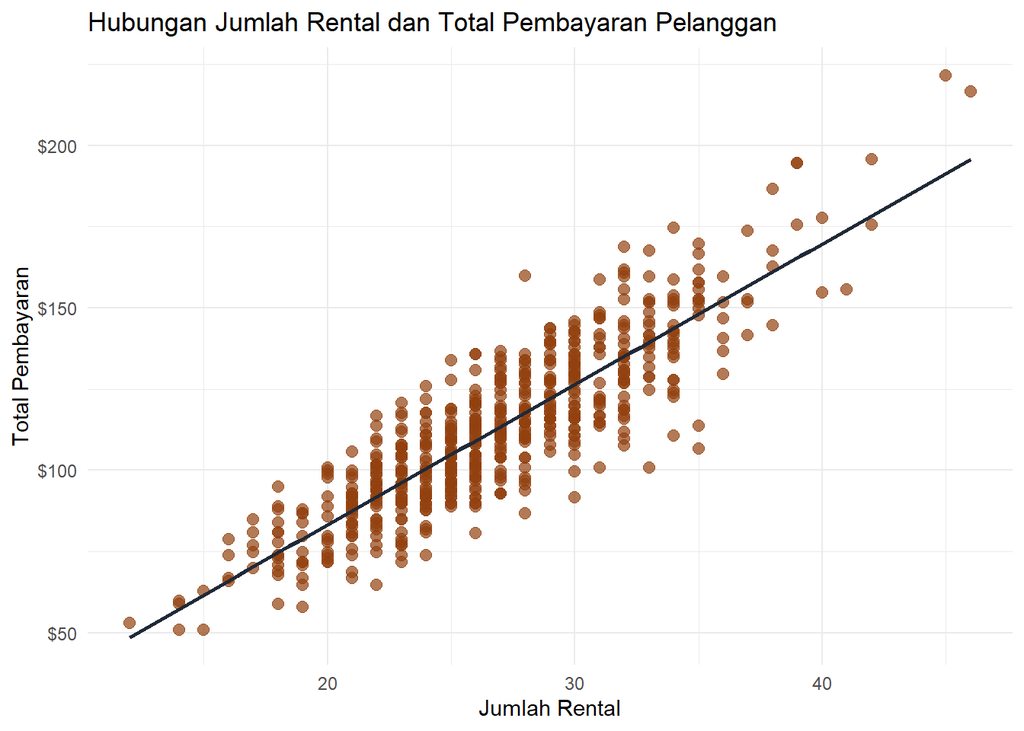

```r
ggplot(data_pelanggan, aes(x = total_rental, y = total_payment)) +
  geom_point(color = "#92400e", size = 2.5, alpha = 0.7) +
  geom_smooth(method = "lm", se = FALSE, color = "#1f2937") +
  scale_y_continuous(labels = dollar_format(prefix = "$")) +
  labs(
    title = "Hubungan Jumlah Rental dan Total Pembayaran Pelanggan",
    x = "Jumlah Rental",
    y = "Total Pembayaran"
  ) +
  theme_minimal()
```

Scatter plot menunjukkan hubungan antara jumlah rental dan total pembayaran pelanggan. Jika pola titik naik, maka pelanggan yang lebih sering melakukan rental cenderung memiliki total pembayaran lebih besar. Namun, pelanggan dengan jumlah rental sedang tetapi pembayaran tinggi juga perlu diperhatikan karena dapat menjadi pelanggan potensial bernilai tinggi.

## 4.3 Analisis Pola Waktu Rental

### 4.3.1 Data Rental Harian

```r
data_waktu_harian <- data_sakila %>%
  group_by(rental_date_only) %>%
  summarise(
    total_rental = n_distinct(rental_id),
    total_revenue = sum(amount, na.rm = TRUE),
    .groups = "drop"
  ) %>%
  arrange(rental_date_only)

kable(head(data_waktu_harian), caption = "Data Rental Harian")
```

Data Rental Harian

| rental_date_only | total_rental | total_revenue |
| --- | --- | --- |
| 2005-05-24 | 8 | 29.92 |
| 2005-05-25 | 137 | 573.63 |
| 2005-05-26 | 174 | 754.26 |
| 2005-05-27 | 166 | 684.34 |
| 2005-05-28 | 196 | 804.04 |
| 2005-05-29 | 154 | 648.46 |

### 4.3.2 Visualisasi Jumlah Rental Film Harian

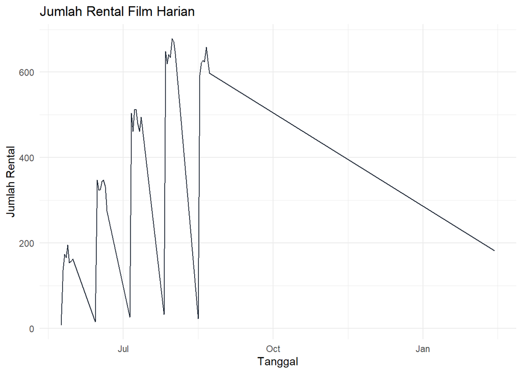

```r
ggplot(data_waktu_harian, aes(x = rental_date_only, y = total_rental)) +
  geom_line(color = "#1f2937") +
  labs(
    title = "Jumlah Rental Film Harian",
    x = "Tanggal",
    y = "Jumlah Rental"
  ) +
  theme_minimal()
```

Grafik jumlah rental harian menunjukkan perubahan aktivitas rental dari waktu ke waktu. Jika terdapat periode dengan jumlah rental lebih tinggi, maka periode tersebut dapat dianggap sebagai waktu dengan permintaan yang relatif besar. Informasi ini penting untuk memahami pola operasional rental film.

### 4.3.3 Heatmap Jumlah Rental Berdasarkan Hari dan Jam

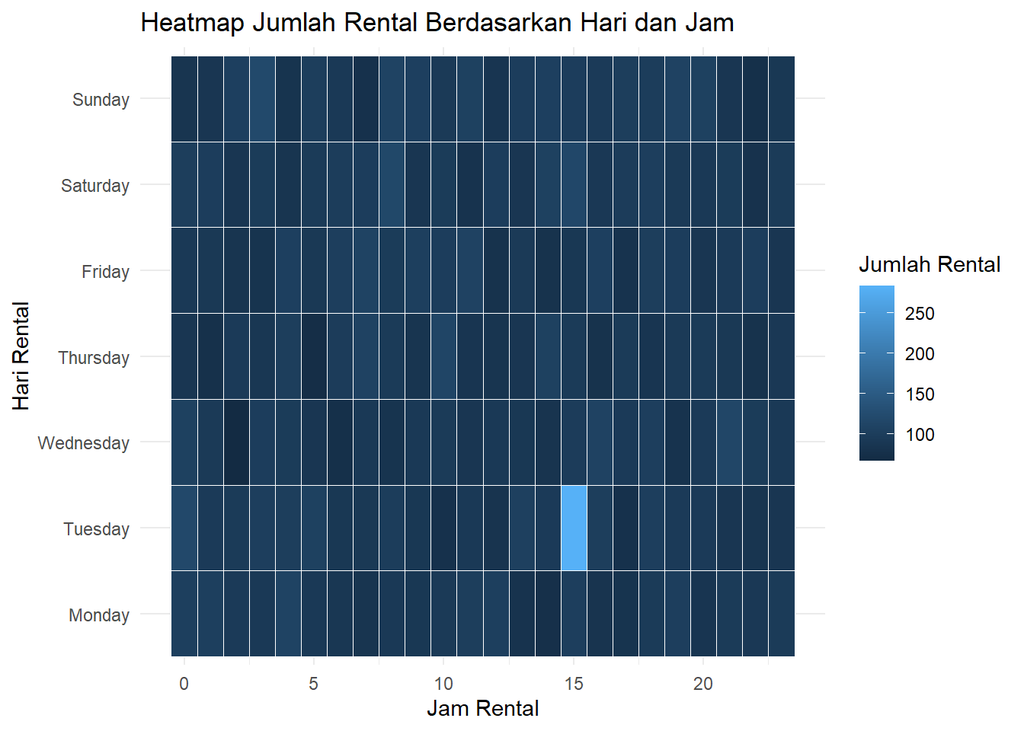

```r
data_waktu_jam <- data_sakila %>%
  group_by(rental_day, rental_hour) %>%
  summarise(
    total_rental = n_distinct(rental_id),
    .groups = "drop"
  )

ggplot(data_waktu_jam, aes(x = rental_hour, y = rental_day, fill = total_rental)) +
  geom_tile(color = "white") +
  labs(
    title = "Heatmap Jumlah Rental Berdasarkan Hari dan Jam",
    x = "Jam Rental",
    y = "Hari Rental",
    fill = "Jumlah Rental"
  ) +
  theme_minimal()
```

Heatmap menunjukkan kombinasi hari dan jam dengan aktivitas rental yang lebih tinggi. Bagian dengan warna lebih kuat menunjukkan waktu dengan jumlah rental lebih besar. Pola ini dapat digunakan untuk memahami waktu sibuk dalam transaksi rental.

# 5 Analisis Regresi Linear Pendapatan Film

Analisis regresi linear digunakan untuk mengevaluasi faktor-faktor yang berhubungan dengan total pendapatan film. Unit observasi pada analisis ini adalah film. Setiap film diringkas berdasarkan jumlah rental, total pendapatan, rata-rata pembayaran, durasi film, rating, tarif rental, dan biaya penggantian.

Model regresi linear yang digunakan adalah:

$$Y = \beta_0 + \beta_1X_1 + \beta_2X_2 +
\beta_3X_3 + \beta_4X_4 + \epsilon$$

dengan:

- $Y$ = total pendapatan film,
- $X_1$ = jumlah rental film,
- $X_2$ = tarif rental film,
- $X_3$ = durasi film,
- $X_4$ = biaya penggantian film,
- $\epsilon$ = error model.

## 5.1 Contoh Dataset Regresi Pendapatan Film

```r
data_film_regresi <- data_sakila %>%
  group_by(film_id, title, rating, length, rental_rate, replacement_cost) %>%
  summarise(
    total_rental = n_distinct(rental_id),
    total_revenue = sum(amount, na.rm = TRUE),
    avg_payment = mean(amount, na.rm = TRUE),
    .groups = "drop"
  )

kable(head(data_film_regresi, 10), caption = "Contoh Dataset Regresi Pendapatan Film", digits = 2)
```

Contoh Dataset Regresi Pendapatan Film

| film_id | title | rating | length | rental_rate | replacement_cost | total_rental | total_revenue | avg_payment |
| --- | --- | --- | --- | --- | --- | --- | --- | --- |
| 1 | ACADEMY DINOSAUR | PG | 86 | 0.99 | 20.99 | 23 | 36.77 | 1.60 |
| 2 | ACE GOLDFINGER | G | 48 | 4.99 | 12.99 | 7 | 52.93 | 7.56 |
| 3 | ADAPTATION HOLES | NC-17 | 50 | 2.99 | 18.99 | 12 | 37.88 | 3.16 |
| 4 | AFFAIR PREJUDICE | G | 117 | 2.99 | 26.99 | 23 | 91.77 | 3.99 |
| 5 | AFRICAN EGG | G | 130 | 2.99 | 22.99 | 12 | 51.88 | 4.32 |
| 6 | AGENT TRUMAN | PG | 169 | 2.99 | 17.99 | 21 | 126.79 | 6.04 |
| 7 | AIRPLANE SIERRA | PG-13 | 62 | 4.99 | 28.99 | 15 | 82.85 | 5.52 |
| 8 | AIRPORT POLLOCK | R | 54 | 4.99 | 15.99 | 18 | 102.82 | 5.71 |
| 9 | ALABAMA DEVIL | PG-13 | 114 | 2.99 | 21.99 | 12 | 71.88 | 5.99 |
| 10 | ALADDIN CALENDAR | NC-17 | 63 | 4.99 | 24.99 | 23 | 131.77 | 5.73 |

## 5.2 Pemodelan Regresi Linear

```r
model_regresi <- lm(
  total_revenue ~ total_rental + rental_rate + length + replacement_cost + rating,
  data = data_film_regresi
)

summary(model_regresi)
```

```
##
## Call:
## lm(formula = total_revenue ~ total_rental + rental_rate + length +
##     replacement_cost + rating, data = data_film_regresi)
##
## Residuals:
##     Min      1Q  Median      3Q     Max
## -50.154 -12.580  -1.162  11.167  85.392
##
## Coefficients:
##                    Estimate Std. Error t value            Pr(>|t|)
## (Intercept)      -49.521352   3.262187 -15.180 <0.0000000000000002 ***
## total_rental       4.312147   0.085014  50.723 <0.0000000000000002 ***
## rental_rate       16.616295   0.344389  48.249 <0.0000000000000002 ***
## length            -0.005642   0.014015  -0.403              0.6874
## replacement_cost   0.024620   0.093695   0.263              0.7928
## ratingNC-17       -1.624162   1.813131  -0.896              0.3706
## ratingPG          -3.165265   1.863238  -1.699              0.0897 .
## ratingPG-13       -2.015242   1.797530  -1.121              0.2625
## ratingR           -1.296691   1.845362  -0.703              0.4824
## ---
## Signif. codes:  0 '***' 0.001 '**' 0.01 '*' 0.05 '.' 0.1 ' ' 1
##
## Residual standard error: 17.44 on 949 degrees of freedom
## Multiple R-squared:  0.8313, Adjusted R-squared:  0.8299
## F-statistic: 584.7 on 8 and 949 DF,  p-value: < 0.00000000000000022
```

```r
tabel_regresi <- tidy(model_regresi)

kable(tabel_regresi, caption = "Koefisien Model Regresi Linear", digits = 4)
```

Koefisien Model Regresi Linear

| term | estimate | std.error | statistic | p.value |
| --- | --- | --- | --- | --- |
| (Intercept) | -49.5214 | 3.2622 | -15.1804 | 0.0000 |
| total_rental | 4.3121 | 0.0850 | 50.7229 | 0.0000 |
| rental_rate | 16.6163 | 0.3444 | 48.2487 | 0.0000 |
| length | -0.0056 | 0.0140 | -0.4026 | 0.6874 |
| replacement_cost | 0.0246 | 0.0937 | 0.2628 | 0.7928 |
| ratingNC-17 | -1.6242 | 1.8131 | -0.8958 | 0.3706 |
| ratingPG | -3.1653 | 1.8632 | -1.6988 | 0.0897 |
| ratingPG-13 | -2.0152 | 1.7975 | -1.1211 | 0.2625 |
| ratingR | -1.2967 | 1.8454 | -0.7027 | 0.4824 |

## 5.3 Visulasiasi Perbandingan Total Pendapatan Aktual dan Prediksi

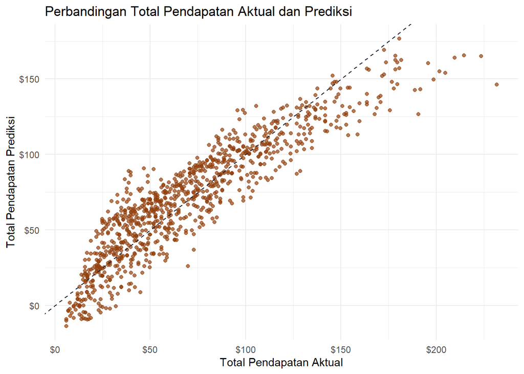

```r
data_film_regresi <- data_film_regresi %>%
  mutate(prediksi_revenue = predict(model_regresi))

ggplot(data_film_regresi, aes(x = total_revenue, y = prediksi_revenue)) +
  geom_point(color = "#92400e", alpha = 0.7) +
  geom_abline(slope = 1, intercept = 0, color = "#1f2937", linetype = "dashed") +
  scale_x_continuous(labels = dollar_format(prefix = "$")) +
  scale_y_continuous(labels = dollar_format(prefix = "$")) +
  labs(
    title = "Perbandingan Total Pendapatan Aktual dan Prediksi",
    x = "Total Pendapatan Aktual",
    y = "Total Pendapatan Prediksi"
  ) +
  theme_minimal()
```

Hasil regresi linear digunakan untuk melihat variabel mana yang berhubungan dengan total pendapatan film. Variabel `total_rental` kemungkinan menjadi faktor yang paling kuat karena total pendapatan secara langsung berkaitan dengan banyaknya transaksi rental. Jika koefisien `total_rental` bernilai positif, maka semakin sering suatu film disewa, semakin besar total pendapatan yang dihasilkan.

Variabel `rental_rate`, `length`, `replacement_cost`, dan `rating` digunakan untuk melihat apakah karakteristik film juga berkaitan dengan pendapatan. Jika terdapat variabel dengan p-value kurang dari 0,05, maka variabel tersebut dapat dianggap memiliki hubungan yang signifikan secara statistik terhadap total pendapatan film pada tingkat signifikansi 5%.

**Catatan:** Regresi linear ini menunjukkan hubungan statistik, bukan hubungan sebab-akibat. Selain itu, total pendapatan secara alami sangat dipengaruhi oleh jumlah rental, sehingga interpretasi perlu dilakukan hati-hati agar tidak menyimpulkan bahwa semua variabel pasti menyebabkan peningkatan pendapatan.

# 6 K-Means Clustering Pelanggan

K-Means Clustering digunakan untuk mengelompokkan pelanggan berdasarkan kemiripan perilaku transaksi. Variabel yang digunakan dalam clustering adalah jumlah rental, total pembayaran, rata-rata pembayaran, dan recency. Recency menunjukkan jarak waktu antara transaksi terakhir pelanggan dan tanggal transaksi paling akhir dalam dataset.

Tujuan dari clustering ini adalah untuk mengidentifikasi kelompok pelanggan seperti pelanggan bernilai tinggi, pelanggan reguler, pelanggan potensial, dan pelanggan dengan aktivitas rendah.

Metode K-Means bekerja dengan meminimumkan variasi dalam klaster:

$$\min \sum_{k=1}^{K} \sum_{i \in C_k}
||x_i - \mu_k||^2$$

dengan:

- $K$ = jumlah klaster,
- $C_k$ = klaster ke-k,
- $x_i$ = data pelanggan ke-i,
- $mu_k$ = pusat klaster ke-k.

## 6.1 Contoh Data Pelanggan untuk Clustering

```r
tanggal_referensi <- max(data_sakila$rental_date, na.rm = TRUE)

data_pelanggan_cluster <- data_sakila %>%
  group_by(customer_id, customer_name) %>%
  summarise(
    total_rental = n_distinct(rental_id),
    total_payment = sum(amount, na.rm = TRUE),
    avg_payment = mean(amount, na.rm = TRUE),
    last_rental_date = max(rental_date, na.rm = TRUE),
    .groups = "drop"
  ) %>%
  mutate(
    recency = as.numeric(difftime(tanggal_referensi, last_rental_date, units = "days"))
  )

kable(head(data_pelanggan_cluster, 10), caption = "Contoh Data Pelanggan untuk Clustering", digits = 2)
```

Contoh Data Pelanggan untuk Clustering

| customer_id | customer_name | total_rental | total_payment | avg_payment | last_rental_date | recency |
| --- | --- | --- | --- | --- | --- | --- |
| 1 | MARY SMITH | 32 | 118.68 | 3.71 | 2005-08-22 20:03:46 | 175.80 |
| 2 | PATRICIA JOHNSON | 27 | 128.73 | 4.77 | 2005-08-23 17:39:35 | 174.90 |
| 3 | LINDA WILLIAMS | 26 | 135.74 | 5.22 | 2005-08-23 07:10:14 | 175.34 |
| 4 | BARBARA JONES | 22 | 81.78 | 3.72 | 2005-08-23 07:43:00 | 175.31 |
| 5 | ELIZABETH BROWN | 38 | 144.62 | 3.81 | 2006-02-14 15:16:03 | 0.00 |
| 6 | JENNIFER DAVIS | 28 | 93.72 | 3.35 | 2005-08-23 06:41:32 | 175.36 |
| 7 | MARIA MILLER | 33 | 151.67 | 4.60 | 2005-08-21 04:49:48 | 177.43 |
| 8 | SUSAN WILSON | 24 | 92.76 | 3.87 | 2005-08-23 14:31:19 | 175.03 |
| 9 | MARGARET MOORE | 23 | 89.77 | 3.90 | 2006-02-14 15:16:03 | 0.00 |
| 10 | DOROTHY TAYLOR | 25 | 99.75 | 3.99 | 2005-08-22 21:59:29 | 175.72 |

## 6.2 Standarisasi Data

```r
data_cluster_scaled <- data_pelanggan_cluster %>%
  select(total_rental, total_payment, avg_payment, recency) %>%
  scale()
```

## 6.3 Penentuan K optimal

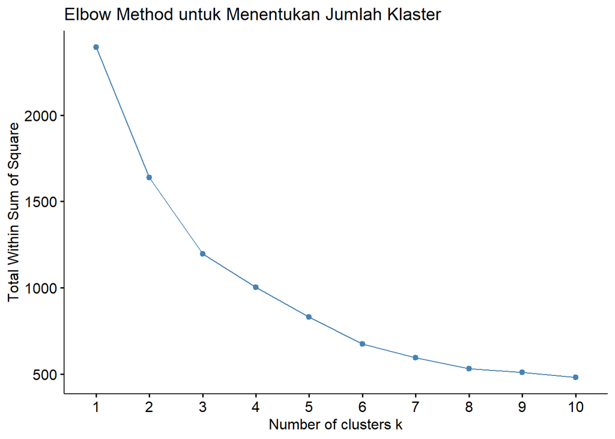

```r
fviz_nbclust(
  data_cluster_scaled,
  kmeans,
  method = "wss"
) +
  labs(title = "Elbow Method untuk Menentukan Jumlah Klaster")
```

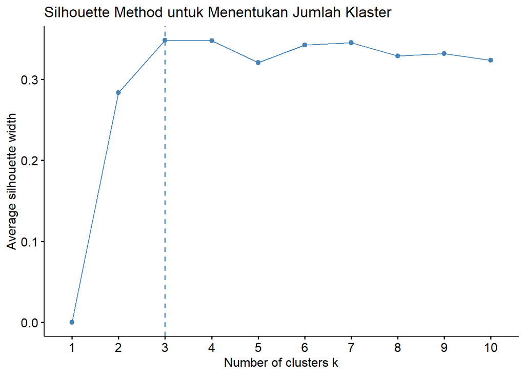

```r
fviz_nbclust(
  data_cluster_scaled,
  kmeans,
  method = "silhouette"
) +
  labs(title = "Silhouette Method untuk Menentukan Jumlah Klaster")
```

```r
sil_width <- sapply(2:6, function(k) {
  model_temp <- kmeans(data_cluster_scaled, centers = k, nstart = 25)
  ss <- silhouette(model_temp$cluster, dist(data_cluster_scaled))
  mean(ss[, 3])
})

k_optimal <- which.max(sil_width) + 1

k_optimal
```

```
## [1] 3
```

## 6.4 Pemodelan K-Means Clustering

```r
model_kmeans <- kmeans(
  data_cluster_scaled,
  centers = k_optimal,
  nstart = 25
)

data_pelanggan_cluster <- data_pelanggan_cluster %>%
  mutate(cluster = as.factor(model_kmeans$cluster))

model_kmeans
```

[output not shown]

## 6.5 Evaluasi Model

```r
# Evaluasi model K-Means final
total_wss <- model_kmeans$tot.withinss
between_ss <- model_kmeans$betweenss
total_ss <- model_kmeans$totss
rasio_between_total <- between_ss / total_ss

# Silhouette untuk model final
sil_final <- silhouette(model_kmeans$cluster, dist(data_cluster_scaled))
avg_sil_final <- mean(sil_final[, 3])

evaluasi_kmeans <- data.frame(
  jumlah_klaster = k_optimal,
  total_wss = round(total_wss, 4),
  between_ss = round(between_ss, 4),
  total_ss = round(total_ss, 4),
  rasio_between_total = round(rasio_between_total, 4),
  avg_silhouette = round(avg_sil_final, 4)
)

kable(
  evaluasi_kmeans,
  caption = "Evaluasi Model K-Means Final"
)
```

Evaluasi Model K-Means Final

| jumlah_klaster | total_wss | between_ss | total_ss | rasio_between_total | avg_silhouette |
| --- | --- | --- | --- | --- | --- |
| 3 | 1197.398 | 1194.602 | 2392 | 0.4994 | 0.3475 |

Model K-Means final menggunakan **3 klaster**. Nilai total WSS sebesar **1197.3983** menunjukkan total variasi dalam klaster. Semakin kecil nilai WSS, semakin kompak anggota dalam klaster tersebut.

Nilai rasio BetweenSS terhadap TotalSS sebesar **0.4994** menunjukkan proporsi variasi data yang dapat dijelaskan oleh pemisahan antar klaster. Semakin besar nilai rasio ini, semakin baik pemisahan antar klaster yang terbentuk.

Nilai rata-rata Silhouette sebesar **0.3475** menunjukkan kualitas pemisahan klaster. Jika nilai Silhouette relatif tinggi, maka pelanggan dalam satu klaster cenderung memiliki karakteristik yang mirip dan cukup berbeda dari pelanggan pada klaster lain. Sebaliknya, jika nilainya rendah, maka terdapat kemungkinan beberapa pelanggan berada di batas antar klaster sehingga pemisahan klaster belum terlalu kuat.

## 6.6 Ukuran Anggota Tiap Klaster

```r
jumlah_anggota_cluster <- data_pelanggan_cluster %>%
  count(cluster) %>%
  mutate(
    persentase = round(n / sum(n) * 100, 2)
  )

kable(
  jumlah_anggota_cluster,
  caption = "Jumlah Anggota pada Setiap Klaster"
)
```

Jumlah Anggota pada Setiap Klaster

| cluster | n | persentase |
| --- | --- | --- |
| 1 | 211 | 35.23 |
| 2 | 247 | 41.24 |
| 3 | 141 | 23.54 |

Jumlah anggota pada setiap klaster digunakan untuk melihat keseimbangan hasil clustering. Jika terdapat satu klaster yang memiliki anggota sangat sedikit, klaster tersebut perlu diperiksa lebih lanjut karena bisa jadi merepresentasikan kelompok pelanggan khusus atau outlier. Sebaliknya, jika semua klaster memiliki jumlah anggota yang relatif seimbang, maka pembagian pelanggan dapat dianggap lebih stabil.

Namun, jumlah anggota yang tidak seimbang tidak selalu berarti buruk. Dalam konteks pelanggan, klaster kecil dapat saja merepresentasikan pelanggan bernilai tinggi atau pelanggan dengan perilaku transaksi yang unik.

## 6.7 Profil Setiap Klaster Pelanggan

```r
profil_cluster_lengkap <- data_pelanggan_cluster %>%
  group_by(cluster) %>%
  summarise(
    jumlah_pelanggan = n(),
    rata_rata_rental = mean(total_rental),
    rata_rata_total_payment = mean(total_payment),
    rata_rata_avg_payment = mean(avg_payment),
    rata_rata_recency = mean(recency),
    .groups = "drop"
  ) %>%
  arrange(desc(rata_rata_total_payment))

kable(
  profil_cluster_lengkap,
  caption = "Profil Lengkap Setiap Klaster Pelanggan",
  digits = 2
)
```

Profil Lengkap Setiap Klaster Pelanggan

| cluster | jumlah_pelanggan | rata_rata_rental | rata_rata_total_payment | rata_rata_avg_payment | rata_rata_recency |
| --- | --- | --- | --- | --- | --- |
| 1 | 211 | 31.05 | 136.94 | 4.43 | 161.35 |
| 3 | 141 | 26.72 | 107.70 | 4.04 | 0.00 |
| 2 | 247 | 23.18 | 94.44 | 4.10 | 175.69 |

Profil klaster digunakan untuk memahami karakteristik setiap kelompok pelanggan. Klaster dengan rata-rata total rental dan total pembayaran tertinggi dapat diinterpretasikan sebagai kelompok pelanggan bernilai tinggi. Pelanggan dalam kelompok ini penting untuk dipertahankan karena memberikan kontribusi besar terhadap pendapatan.

Klaster dengan rata-rata rental sedang dan total pembayaran sedang dapat diinterpretasikan sebagai pelanggan reguler. Kelompok ini memiliki aktivitas transaksi yang cukup stabil dan berpotensi ditingkatkan melalui promosi atau rekomendasi film yang lebih sesuai.

Sementara itu, klaster dengan rata-rata rental rendah, total pembayaran rendah, dan recency tinggi dapat diinterpretasikan sebagai pelanggan kurang aktif. Kelompok ini dapat menjadi target strategi reaktivasi, misalnya melalui promo khusus atau rekomendasi film berdasarkan kategori yang pernah disewa.

## 6.8 Pemberian Label Klaster

```r
profil_cluster_label <- data_pelanggan_cluster %>%
  group_by(cluster) %>%
  summarise(
    rata_rata_rental = mean(total_rental),
    rata_rata_total_payment = mean(total_payment),
    rata_rata_recency = mean(recency),
    .groups = "drop"
  ) %>%
  mutate(
    label_cluster = case_when(
      rata_rata_rental == max(rata_rata_rental) &
        rata_rata_total_payment == max(rata_rata_total_payment) ~ "High Value Customer",

      rata_rata_recency == max(rata_rata_recency) &
        rata_rata_total_payment == min(rata_rata_total_payment) ~ "Low Activity Customer",

      rata_rata_total_payment >= median(rata_rata_total_payment) ~ "Regular Profitable Customer",

      TRUE ~ "Regular Customer"
    )
  )

data_pelanggan_cluster <- data_pelanggan_cluster %>%
  left_join(
    profil_cluster_label %>% select(cluster, label_cluster),
    by = "cluster"
  )

kable(
  profil_cluster_label,
  caption = "Label Interpretasi Setiap Klaster",
  digits = 2
)
```

Label Interpretasi Setiap Klaster

| cluster | rata_rata_rental | rata_rata_total_payment | rata_rata_recency | label_cluster |
| --- | --- | --- | --- | --- |
| 1 | 31.05 | 136.94 | 161.35 | High Value Customer |
| 2 | 23.18 | 94.44 | 175.69 | Low Activity Customer |
| 3 | 26.72 | 107.70 | 0.00 | Regular Profitable Customer |

Pemberian label klaster dilakukan agar hasil K-Means lebih mudah dipahami secara bisnis. Nomor klaster seperti 1, 2, atau 3 tidak memiliki makna khusus, sehingga setiap klaster perlu diberi nama berdasarkan karakteristik rata-ratanya. Label seperti High Value Customer, Regular Customer, atau Low Activity Customer membantu menjelaskan perbedaan perilaku pelanggan secara lebih intuitif.

## 6.9 Visualisasi K-Means Clustering Pelanggan

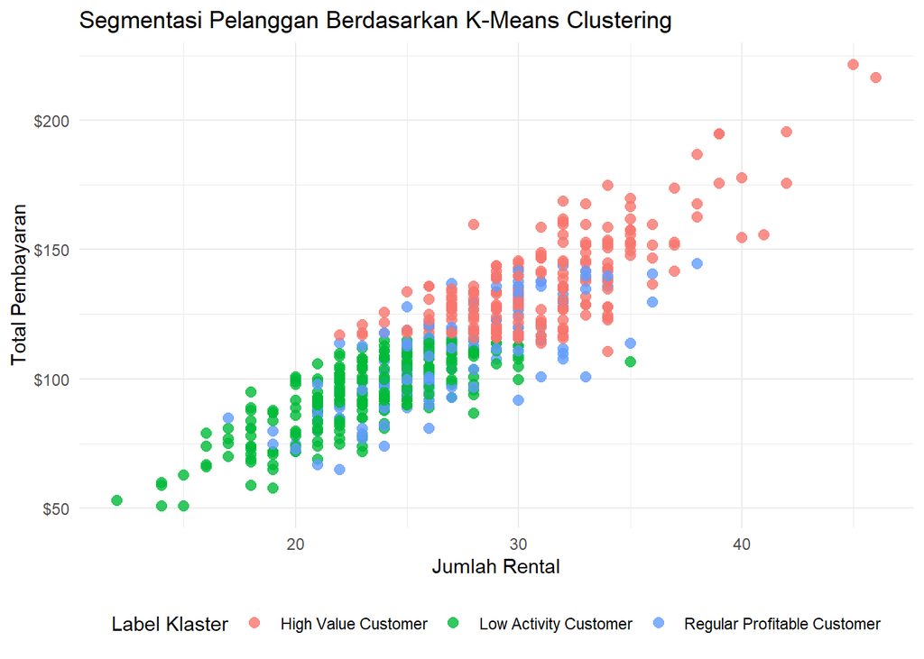

```r
ggplot(
  data_pelanggan_cluster,
  aes(x = total_rental, y = total_payment, color = label_cluster)
) +
  geom_point(size = 2.5, alpha = 0.8) +
  scale_y_continuous(labels = dollar_format(prefix = "$")) +
  labs(
    title = "Segmentasi Pelanggan Berdasarkan K-Means Clustering",
    x = "Jumlah Rental",
    y = "Total Pembayaran",
    color = "Label Klaster"
  ) +
  theme_minimal() +
  theme(
    legend.position = "bottom"
  )
```

Hasil K-Means Clustering menunjukkan bahwa pelanggan dapat dikelompokkan berdasarkan pola transaksi yang berbeda. Klaster dengan rata-rata jumlah rental dan total pembayaran tinggi dapat diinterpretasikan sebagai kelompok pelanggan bernilai tinggi. Klaster dengan jumlah rental rendah dan recency tinggi dapat diinterpretasikan sebagai pelanggan yang relatif kurang aktif. Sementara itu, klaster dengan nilai transaksi sedang dapat dianggap sebagai pelanggan reguler.

Interpretasi klaster sebaiknya dilakukan berdasarkan tabel profil klaster, bukan hanya berdasarkan nomor klaster. Nomor klaster seperti 1, 2, atau 3 tidak memiliki makna khusus sampai dilihat karakteristik rata-ratanya.

**Kesimpulan sementara:** Clustering menunjukkan bahwa pelanggan dalam database Sakila tidak memiliki perilaku transaksi yang seragam. Oleh karena itu, strategi bisnis sebaiknya dibedakan untuk setiap kelompok pelanggan. Pelanggan bernilai tinggi perlu dipertahankan, pelanggan reguler dapat ditingkatkan nilai transaksinya, sedangkan pelanggan kurang aktif dapat menjadi target promosi reaktivasi.

# 7 Prediksi Keterlambatan Pengembalian Film

Analisis prediksi dilakukan menggunakan regresi logistik untuk memetakan risiko keterlambatan pengembalian film. Variabel target yang digunakan adalah `late_return`, yaitu status apakah durasi aktual rental lebih lama daripada durasi rental yang ditentukan pada data film.

Regresi logistik digunakan karena variabel target berbentuk biner, yaitu `Terlambat` dan `Tidak Terlambat`.

Model regresi logistik dapat ditulis sebagai:

$$log\left(\frac{p}{1-p}\right) = \beta_0
+ \beta_1X_1 + \beta_2X_2 + ... + \beta_kX_k$$

dengan:

- $p$ = peluang terjadinya keterlambatan pengembalian,
- $1-p$ = peluang tidak terlambat,
- $X_k$ = variabel prediktor,
- $beta_k$ = koefisien model.

## 7.1 Pembentukan Variabel Baru

```r
data_prediksi <- data_sakila_returned %>%
  mutate(
    late_return = ifelse(actual_rental_duration > rental_duration, 1, 0),
    late_return = factor(
      late_return,
      levels = c(0, 1),
      labels = c("Tidak Terlambat", "Terlambat")
    ),
    rating = as.factor(rating),
    category = as.factor(category),
    store_id = as.factor(store_id)
  ) %>%
  select(
    late_return,
    rental_rate,
    rental_duration,
    length,
    replacement_cost,
    rating,
    category,
    rental_hour,
    store_id
  )

table(data_prediksi$late_return)
```

```
##
## Tidak Terlambat       Terlambat
##            7740            8121
```

Variabel `late_return` dibentuk dengan membandingkan `actual_rental_duration` dan `rental_duration`. Jika durasi aktual rental lebih besar dari durasi rental yang ditentukan, maka transaksi dikategorikan sebagai terlambat. Data yang digunakan hanya data yang memiliki `return_date`, karena transaksi tanpa tanggal pengembalian tidak dapat dihitung durasi aktualnya.

## 7.2 Split Data

```r
set.seed(123)

index_train <- createDataPartition(
  data_prediksi$late_return,
  p = 0.8,
  list = FALSE
)

train_data <- data_prediksi[index_train, ]
test_data <- data_prediksi[-index_train, ]
```

## 7.3 Pemodelan Regresi Logistik

```r
model_logistik <- glm(
  late_return ~ rental_rate + rental_duration + length + replacement_cost + rating + rental_hour + store_id,
  data = train_data,
  family = binomial
)

summary(model_logistik)
```

```
##
## Call:
## glm(formula = late_return ~ rental_rate + rental_duration + length +
##     replacement_cost + rating + rental_hour + store_id, family = binomial,
##     data = train_data)
##
## Coefficients:
##                     Estimate  Std. Error z value            Pr(>|z|)
## (Intercept)       2.22440660  0.12268352  18.131 <0.0000000000000002 ***
## rental_rate      -0.00042841  0.01135018  -0.038              0.9699
## rental_duration  -0.45583416  0.01386642 -32.873 <0.0000000000000002 ***
## length           -0.00048494  0.00046923  -1.033              0.3014
## replacement_cost  0.00600856  0.00307470   1.954              0.0507 .
## ratingNC-17       0.06426844  0.06110850   1.052              0.2929
## ratingPG         -0.00411127  0.06149896  -0.067              0.9467
## ratingPG-13       0.05398033  0.05991281   0.901              0.3676
## ratingR           0.00354189  0.06170243   0.057              0.9542
## rental_hour       0.00003467  0.00270763   0.013              0.9898
## store_id2        -0.02176698  0.03730232  -0.584              0.5595
## ---
## Signif. codes:  0 '***' 0.001 '**' 0.01 '*' 0.05 '.' 0.1 ' ' 1
##
## (Dispersion parameter for binomial family taken to be 1)
##
##     Null deviance: 17583  on 12688  degrees of freedom
## Residual deviance: 16384  on 12678  degrees of freedom
## AIC: 16406
##
## Number of Fisher Scoring iterations: 4
```

## 7.4 Evaluasi Model

```r
prob_prediksi <- predict(
  model_logistik,
  newdata = test_data,
  type = "response"
)

kelas_prediksi <- ifelse(prob_prediksi >= 0.5, "Terlambat", "Tidak Terlambat")

kelas_prediksi <- factor(
  kelas_prediksi,
  levels = c("Tidak Terlambat", "Terlambat")
)

conf_matrix <- confusionMatrix(
  kelas_prediksi,
  test_data$late_return,
  positive = "Terlambat"
)

conf_matrix
```

```
## Confusion Matrix and Statistics
##
##                  Reference
## Prediction        Tidak Terlambat Terlambat
##   Tidak Terlambat             923       557
##   Terlambat                   625      1067
##
##                Accuracy : 0.6274
##                  95% CI : (0.6103, 0.6442)
##     No Information Rate : 0.512
##     P-Value [Acc > NIR] : < 0.0000000000000002
##
##                   Kappa : 0.2535
##
##  Mcnemar's Test P-Value : 0.05132
##
##             Sensitivity : 0.6570
##             Specificity : 0.5963
##          Pos Pred Value : 0.6306
##          Neg Pred Value : 0.6236
##              Prevalence : 0.5120
##          Detection Rate : 0.3364
##    Detection Prevalence : 0.5334
##       Balanced Accuracy : 0.6266
##
##        'Positive' Class : Terlambat
##
```

```r
roc_model <- roc(
  response = test_data$late_return,
  predictor = prob_prediksi,
  levels = c("Tidak Terlambat", "Terlambat")
)
auc_model <- auc(roc_model)

auc_model
```

```
## Area under the curve: 0.6734
```

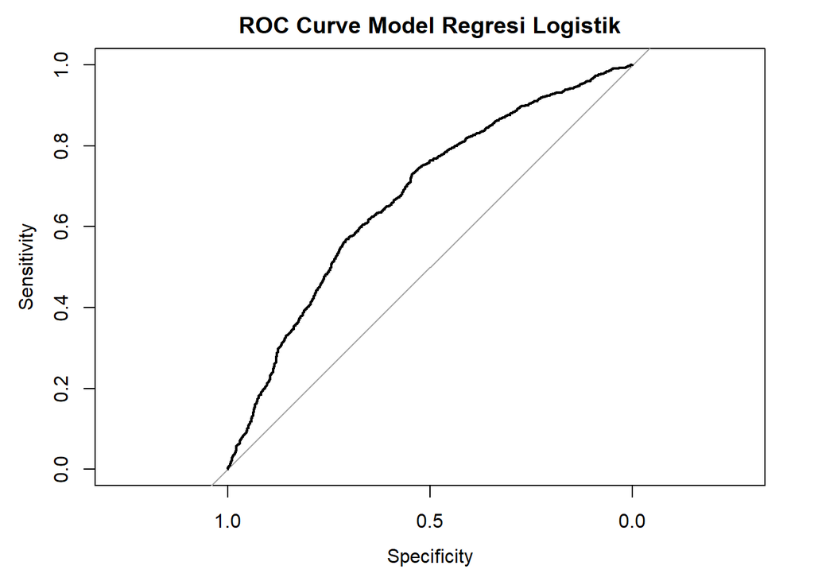

```r
plot(
  roc_model,
  main = "ROC Curve Model Regresi Logistik"
)
```

Regresi logistik digunakan untuk memprediksi apakah suatu transaksi rental berisiko mengalami keterlambatan pengembalian. Hasil confusion matrix menunjukkan kemampuan model dalam mengklasifikasikan transaksi ke dalam kategori terlambat dan tidak terlambat. Metrik seperti accuracy, sensitivity, specificity, dan AUC digunakan untuk mengevaluasi performa model.

Nilai AUC sebesar **0.673** menunjukkan kemampuan model dalam membedakan transaksi yang terlambat dan tidak terlambat. Jika nilai AUC mendekati 1, maka kemampuan diskriminasi model semakin baik. Sebaliknya, jika nilai AUC mendekati 0,5, maka kemampuan model tidak jauh berbeda dari tebakan acak.

**Catatan:** Variabel `actual_rental_duration` tidak digunakan sebagai prediktor karena variabel tersebut secara langsung membentuk target `late_return`. Jika digunakan, model akan mengalami data leakage, yaitu kondisi ketika model menggunakan informasi yang seharusnya belum diketahui saat prediksi dilakukan.

**Kesimpulan sementara:** Model regresi logistik dapat digunakan sebagai simulasi awal untuk memprediksi risiko keterlambatan pengembalian film. Namun, performa model tetap perlu ditafsirkan secara hati-hati karena database Sakila tidak memuat faktor eksternal seperti alasan keterlambatan, kondisi pelanggan, kebijakan denda, atau preferensi pelanggan.

# 8 Kesimpulan dan Rekomendasi

Berdasarkan hasil analisis terhadap database Sakila, dapat disimpulkan bahwa performa bisnis rental film dapat dipahami melalui beberapa aspek utama, yaitu kategori film, perilaku pelanggan, karakteristik film, pola waktu rental, dan risiko keterlambatan pengembalian.

Analisis eksploratif menunjukkan bahwa kategori film memiliki kontribusi pendapatan dan jumlah rental yang berbeda-beda. Kategori dengan jumlah rental tinggi menunjukkan tingkat popularitas yang besar, sedangkan kategori dengan total pendapatan tinggi menunjukkan kontribusi finansial yang lebih kuat. Oleh karena itu, pengelolaan inventaris film sebaiknya tidak hanya mempertimbangkan jumlah film yang disewa, tetapi juga pendapatan yang dihasilkan.

Hasil K-Means Clustering menunjukkan bahwa pelanggan dapat dikelompokkan berdasarkan perilaku transaksi. Kelompok pelanggan bernilai tinggi perlu dipertahankan melalui strategi loyalitas, sedangkan pelanggan dengan aktivitas rendah dapat menjadi sasaran promosi agar kembali aktif melakukan rental. Segmentasi ini menunjukkan bahwa pelanggan tidak dapat diperlakukan secara seragam karena setiap kelompok memiliki pola transaksi yang berbeda.

Analisis prediksi keterlambatan pengembalian menggunakan regresi logistik menunjukkan bahwa risiko keterlambatan dapat dimodelkan berdasarkan beberapa karakteristik transaksi dan film. Namun, hasil prediksi masih terbatas karena data Sakila tidak memuat faktor perilaku pelanggan secara mendalam maupun faktor eksternal lain yang mungkin memengaruhi keterlambatan.

## 8.1 Rekomendasi

1. Kategori film dengan total pendapatan tinggi sebaiknya diprioritaskan dalam pengelolaan stok karena memiliki kontribusi finansial besar.
2. Pelanggan bernilai tinggi perlu dipertahankan melalui strategi loyalitas, seperti rekomendasi film, promo khusus, atau layanan prioritas.
3. Pelanggan dengan aktivitas rendah dapat menjadi target promosi reaktivasi agar kembali melakukan transaksi rental.
4. Pola waktu rental dapat digunakan untuk mengatur strategi operasional, seperti kesiapan staf dan promosi pada waktu dengan aktivitas tinggi.
5. Model prediksi keterlambatan dapat dikembangkan lebih lanjut dengan menambahkan variabel perilaku pelanggan, riwayat keterlambatan, atau data eksternal lain agar hasil prediksi lebih akurat.